# Technical Analysis using R – Preliminary Stage

BDA400 Assignment 2

Nadeeka (Student ID: 664430944)

November 13, 2026

# 1. Setup

Load the packages used for technical analysis. They were installed once with `install.packages(c("quantmod", "TTR"))`.

```r
library(quantmod)   # getSymbols(), chartSeries()
library(TTR)        # SMA() moving average
```

# 2. Project Configuration

The list of stock symbols making up the portfolio is stored in a plain text file, `portfolio.txt`, one symbol per line. This keeps the portfolio easy to edit without touching the code.

```r
portfolio_path <- "portfolio.txt"
cat(readLines(portfolio_path), sep = "\n")
```

```
## AAPL
## MSFT
## GOOGL
## AMZN
## TSLA
```

# 3. Function: Import and Load Stock Data

`load_stock_data()` reads the symbols from `portfolio.txt` and downloads historical OHLC (Open/High/Low/Close/Volume/Adjusted) data for each symbol using `quantmod::getSymbols()`. Each stock’s data is returned as a separate `xts`/data frame object inside a named list, keyed by ticker symbol.

```r
load_stock_data <- function(portfolio_file = "portfolio.txt",
                            src = "yahoo",
                            from = Sys.Date() - 365,
                            to = Sys.Date()) {

  # Read the stock symbols from the portfolio file, one per line
  symbols <- readLines(portfolio_file)
  symbols <- trimws(symbols)
  symbols <- symbols[symbols != ""]

  stock_data <- list()

  for (sym in symbols) {
    message("Downloading data for: ", sym)

    result <- tryCatch({
      getSymbols(sym,
                 src = src,
                 from = from,
                 to = to,
                 auto.assign = FALSE)
    }, error = function(e) {
      warning("Failed to download ", sym, ": ", conditionMessage(e))
      NULL
    })

    if (!is.null(result)) {
      # Convert xts to a data frame with a Date column and clean names
      df <- data.frame(Date = index(result), coredata(result))
      colnames(df) <- c("Date", "Open", "High", "Low", "Close", "Volume", "Adjusted")
      stock_data[[sym]] <- df
    }
  }

  return(stock_data)
}
```

The analysis window is fixed to one year (24 Aug 2025 – 24 Aug 2026) so the results are reproducible.

```r
stocks <- load_stock_data("portfolio.txt",
                          from = as.Date("2025-08-24"),
                          to   = as.Date("2026-08-24"))
names(stocks)
```

```
## [1] "AAPL"  "MSFT"  "GOOGL" "AMZN"  "TSLA"
```

```r
sapply(stocks, nrow)
```

```
##  AAPL  MSFT GOOGL  AMZN  TSLA
##   250   250   250   250   250
```

# 4. Function: Compute Basic Statistics

`calculate_statistics()` takes a single stock’s data frame (as produced by `load_stock_data()`) and computes:

- **Moving average** (20-day Simple Moving Average of the closing price, via `TTR::SMA`)
- **Mean** closing price
- **Mode** closing price (R has no built-in `mode()` for this, so a helper is defined)
- **Median** closing price
- **Standard deviation** of the closing price

```r
# Base R has no statistical mode function - define one
get_mode <- function(x) {
  x <- x[!is.na(x)]
  ux <- unique(x)
  ux[which.max(tabulate(match(x, ux)))]
}
```

```r
calculate_statistics <- function(stock_df, ma_period = 20) {

  close_prices <- stock_df$Close

  moving_avg <- TTR::SMA(close_prices, n = ma_period)

  summary_stats <- data.frame(
    Mean        = mean(close_prices, na.rm = TRUE),
    Mode        = get_mode(close_prices),
    Median      = median(close_prices, na.rm = TRUE),
    SD          = sd(close_prices, na.rm = TRUE),
    Latest_MA20 = tail(moving_avg, 1)
  )

  list(summary_stats = summary_stats,
       moving_average = moving_avg)
}

all_stats <- lapply(stocks, calculate_statistics)
```

# 5. Display Utilities

## 5.1 Display the loaded data

```r
display_stock_data <- function(stock_list, n = 5) {
  for (sym in names(stock_list)) {
    df <- stock_list[[sym]]
    cat("\n=====", sym, "=====",
        nrow(df), "trading days from", format(min(df$Date)),
        "to", format(max(df$Date)), "\n")
    print(head(df, n), row.names = FALSE)
  }
}

display_stock_data(stocks)
```

```
##
## ===== AAPL ===== 250 trading days from 2025-08-25 to 2026-08-21
##        Date   Open   High    Low  Close   Volume Adjusted
##  2025-08-25 226.48 229.30 226.23 227.16 30983100 226.1521
##  2025-08-26 226.87 229.49 224.69 229.31 54575100 228.2926
##  2025-08-27 228.61 230.90 228.26 230.49 31259500 229.4674
##  2025-08-28 230.82 233.41 229.34 232.56 38074700 231.5282
##  2025-08-29 232.51 233.38 231.37 232.14 39418400 231.1100
##
## ===== MSFT ===== 250 trading days from 2025-08-25 to 2026-08-21
##        Date   Open   High    Low  Close   Volume Adjusted
##  2025-08-25 506.63 508.19 504.12 504.26 21638600 500.1450
##  2025-08-26 504.36 504.98 498.51 502.04 30835700 497.9431
##  2025-08-27 502.00 507.29 499.90 506.74 17277900 502.6047
##  2025-08-28 507.09 511.09 505.50 509.64 18015600 505.4811
##  2025-08-29 508.66 509.60 504.49 506.69 20961600 502.5551
##
## ===== GOOGL ===== 250 trading days from 2025-08-25 to 2026-08-21
##        Date   Open   High    Low  Close   Volume Adjusted
##  2025-08-25 206.43 210.52 205.28 208.49 29928900 207.7634
##  2025-08-26 207.51 207.85 205.70 207.14 28464100 206.4181
##  2025-08-27 205.70 208.91 205.65 207.48 23022900 206.7569
##  2025-08-28 207.25 212.22 206.90 211.64 32339300 210.9024
##  2025-08-29 210.51 214.65 210.20 212.91 39728400 212.1680
##
## ===== AMZN ===== 250 trading days from 2025-08-25 to 2026-08-21
##        Date   Open   High    Low  Close   Volume Adjusted
##  2025-08-25 227.35 229.60 227.31 227.94 22633700   227.94
##  2025-08-26 227.11 229.00 226.02 228.71 26105400   228.71
##  2025-08-27 228.57 229.87 227.81 229.12 21254500   229.12
##  2025-08-28 229.01 232.71 228.02 231.60 33679600   231.60
##  2025-08-29 231.32 231.81 228.16 229.00 26199200   229.00
##
## ===== TSLA ===== 250 trading days from 2025-08-25 to 2026-08-21
##        Date   Open   High    Low  Close   Volume Adjusted
##  2025-08-25 338.90 349.53 335.03 346.60 86670000   346.60
##  2025-08-26 344.93 351.90 343.72 351.67 76651600   351.67
##  2025-08-27 351.94 355.39 349.16 349.60 65519000   349.60
##  2025-08-28 350.91 353.55 340.26 345.98 67903200   345.98
##  2025-08-29 347.23 348.75 331.70 333.87 81145700   333.87
```

## 5.2 Display computed statistics (table form)

```r
display_statistics <- function(stats_list) {
  combined <- do.call(rbind, lapply(names(stats_list), function(sym) {
    row <- stats_list[[sym]]$summary_stats
    cbind(Symbol = sym, row)
  }))
  rownames(combined) <- NULL
  combined
}

display_statistics(all_stats)
```

```
##   Symbol     Mean   Mode  Median       SD Latest_MA20
## 1   AAPL 275.0161 237.88 270.840 25.09897    314.3385
## 2   MSFT 447.8545 483.47 450.670 52.14516    473.0920
## 3  GOOGL 315.5022 318.58 317.470 45.48056    348.3970
## 4   AMZN 235.8596 222.69 232.930 19.38118    261.3785
## 5   TSLA 405.2978 429.24 410.015 40.59445    328.1420
```

## 5.3 Visualize: price chart with moving average

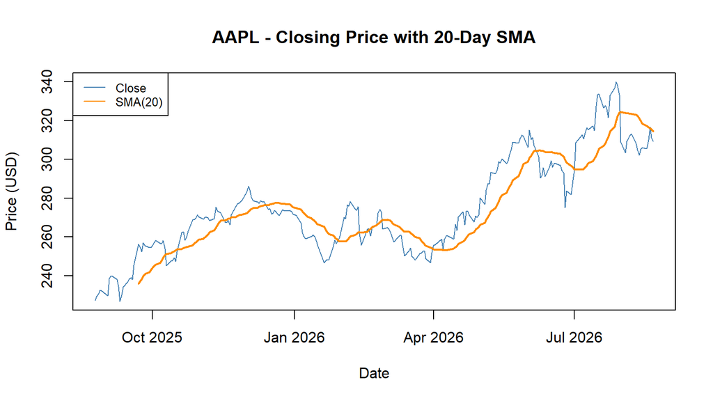

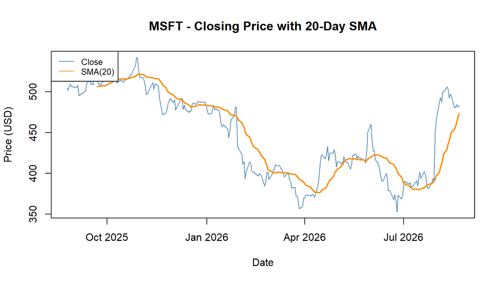

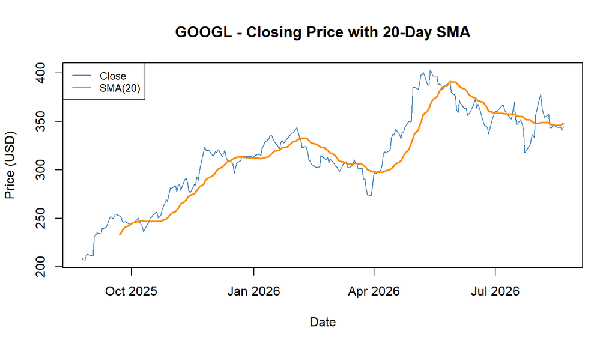

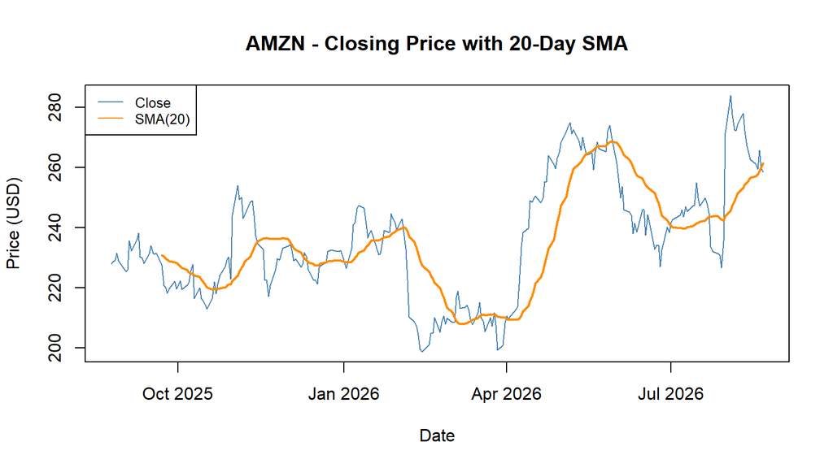

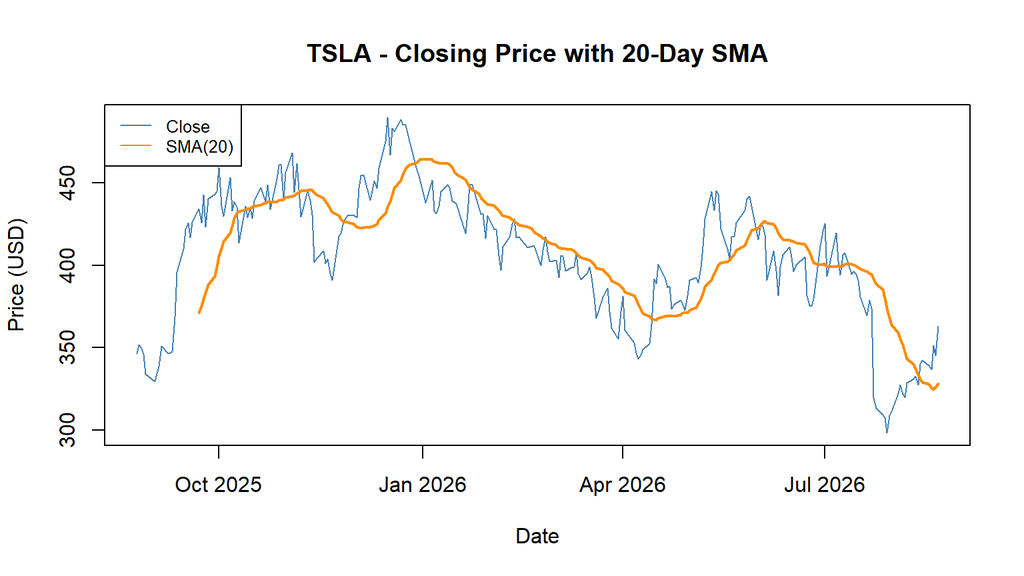

```r
for (sym in names(stocks)) {
  df <- stocks[[sym]]
  ma <- all_stats[[sym]]$moving_average

  plot(df$Date, df$Close, type = "l",
       main = paste(sym, "- Closing Price with 20-Day SMA"),
       xlab = "Date", ylab = "Price (USD)", col = "steelblue")
  lines(df$Date, ma, col = "darkorange", lwd = 2)
  legend("topleft", legend = c("Close", "SMA(20)"),
         col = c("steelblue", "darkorange"), lty = 1, cex = 0.8)
}
```

## 5.4 Visualize: candlestick chart (quantmod)

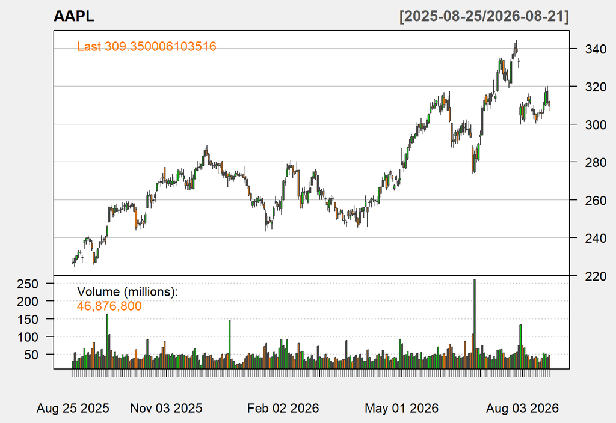

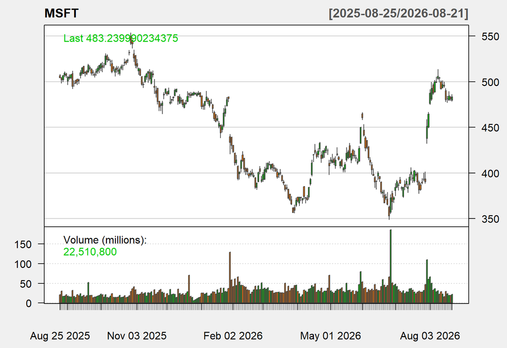

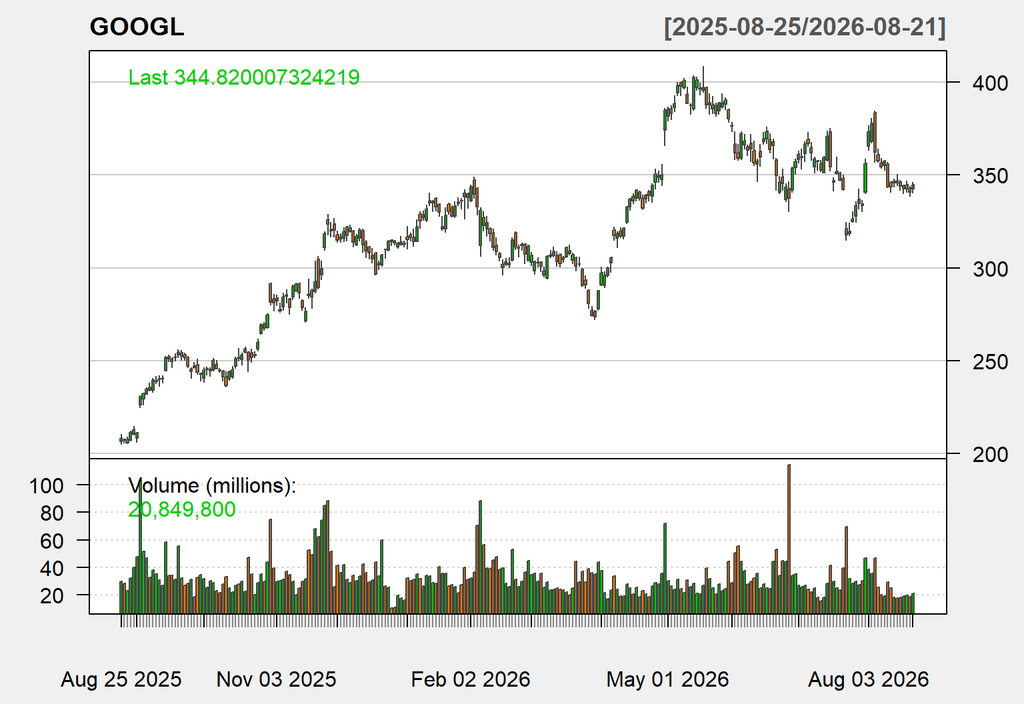

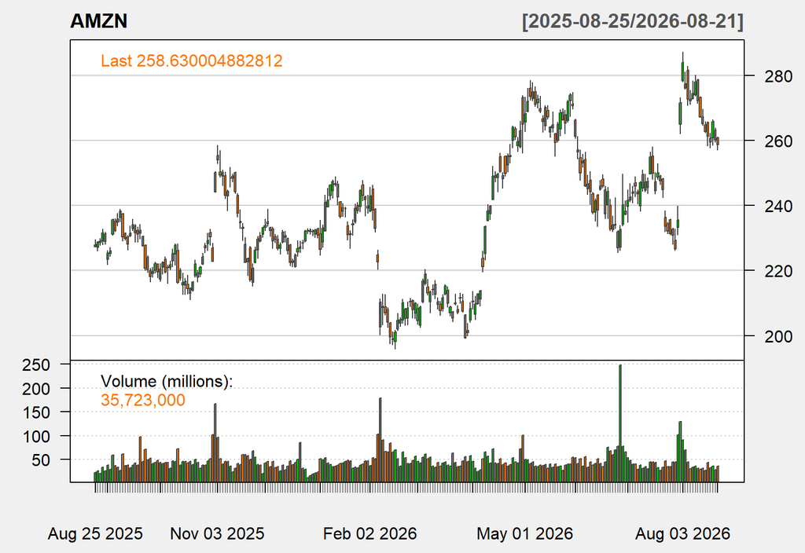

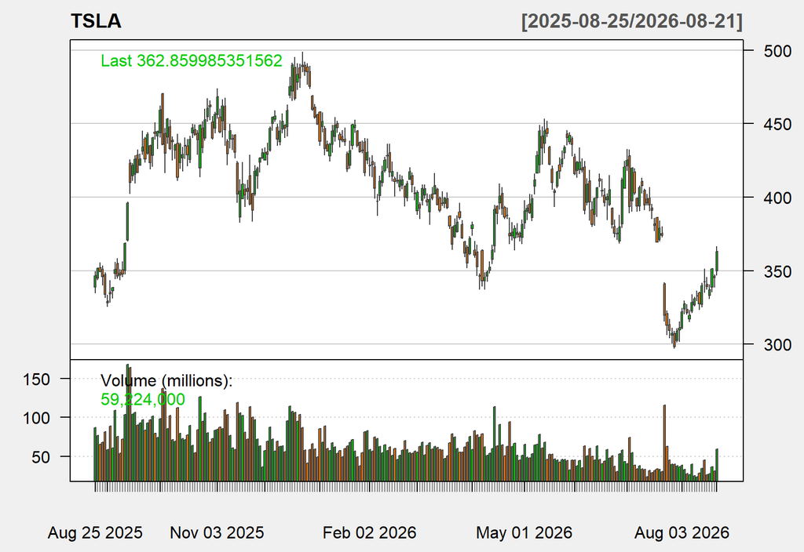

```r
for (sym in names(stocks)) {
  df <- stocks[[sym]]
  xts_obj <- xts::xts(df[, c("Open", "High", "Low", "Close", "Volume", "Adjusted")],
                      order.by = df$Date)
  chartSeries(xts_obj, name = sym, theme = chartTheme("white"))
}
```

# 6. Summary

This preliminary stage set up the project scaffolding for the technical analysis project:

- `portfolio.txt` holds the five ticker symbols (AAPL, MSFT, GOOGL, AMZN, TSLA).
- `load_stock_data()` imports one year of daily prices for every symbol with **quantmod** and stores each stock as its own data frame.
- `calculate_statistics()` computes the 20-day moving average, mean, mode, median and standard deviation of the closing price.
- `display_stock_data()`, `display_statistics()` and the chart loops display the data as tables, line charts and candlestick charts.

These functions will be reused and extended in the next two stages of the project.